## **Exploring the influence of nutrition on the duration of singing in *Gryllodes sigillatus,* the decorated cricket - does diet quality affect sexual signalling?**

### **Introduction**

*Gryllodes sigillatus* is a species of cricket known by many names including decorated, banded, and tropical house cricket; males of the species use a calling song to attract a female mate. The signalling song produced by males is facilitated by the orthopteran insect’s forewings and antennae, working as a sexual signalling display to attract a female mate (Subramaniam and Subramoniam 1990). It has been found that the duration of the song produced is influential, with females being drawn to and preferring to mate with individuals that can produce a longer song (Kiflawi and Gray 2000). The song can be so alluring to the female that if other crickets’ songs can be heard nearby, a male cricket will increasingly engage in mate guarding behaviours - actions such as isolating the mated female in a burrow work to ensure paternity by preventing the female from mating multiple times (Bateman and MacFadyen 1999). Not only does a male’s song work to attract females and dissuade possible rival males, but female *Gryllodes sigillatus* crickets exposed to the acoustic displays of their own species reach their full mass quicker than females exposed to either heterospecific songs from different species or no songs at all (Bateman, Verburgt, and Ferguson 2005). This would mean that the females can reach sexual maturity quicker when in the presence of viable mates.

Due to the importance of sexual signalling displays for a cricket’s ability to reproduce, this paper aims to look at factors that can influence singing ability, specifically the effects of nutrition on male individuals. I hypothesize that males with a more nutritious diet will have a greater increase in weight. As a result of this, I also predict that individuals will sing for a greater duration if their diet has a greater nutritional percentage, as more resources can be allocated to the costly signalling act.

### **Analysis**

The data set used to investigate the hypotheses detailed above contains information collected over the course of a week pertaining to male crickets’ nutrition, song duration, weight change, and size. R version 4.2.3 (R Core Team 2023) was used to analyse the data and investigate which of the recorded factors influence song duration.

When investigating the minimum and maximum data points, a negative value for song duration became apparent. Believing this to be a typing error, the absolute values were used for song duration so as to avoid any impossible values. Only this variable was altered in such a way, as negative values are valid for other variables such as weight change.

A secondary ordinary least squares linear model was created to assess the weight change of crickets with the nutritional percentage of their diet as a categorical predictor. This was done in order to address the hypothesis that diet has an impact on weight change.

The following packages were used during the data analysis and visualisation process: tidyverse to transform and present data (Wickham et al. 2019), colorBlindness to check plot accessibility (Ou 2021), rstatix for statistical tests (Kassambara 2021), performance for evaluating the fit of models (Lüdecke et al. 2021), MASS to perform boxcox function (Venables and Ripley 2002), broom to tidy data and outputs (Robinson, Hayes, and Couch 2022), and patchwork to combine multiple plots into single visuals (Pedersen 2022).

### **Results & Discussion**

##### **WEIGHT CHANGE**

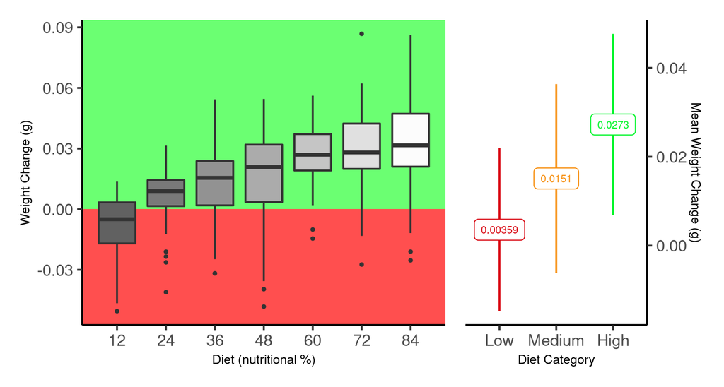

**Fig.1 - LEFT**: Weight gain (grams) in *Gryllodes sigillatus* increases with the nutritional percentage of the crickets diet (12-84%) over the observational period of one week (n=539). Each 12% increase in nutrition was shown to correspond with an additional weight gain of 0.00596 grams [95% CI; 0.00553-0.00639]. The region highlighted in red represents a loss of weight while the green region conversely represents weight gain. The median, interquartile range, and range for each nutritional percentage are respectively illustrated by the middle line, box, and whiskers on their plot. Outliers are represented by circular plots. **RIGHT:** The mean weight change in grams is presented to 3 significant figures for each nutritional category - Low (<=36%), Medium(=48%), and High(>=60%). Error bars extend one standard deviation above and below the mean.

##### **SONG DURATION**

This is consistent with the previous knowledge on resource allocation (Ketola and Kotiaho 2009), as acoustic production in crickets is a highly energetic process which would require an abundance of resources derived from their diet.

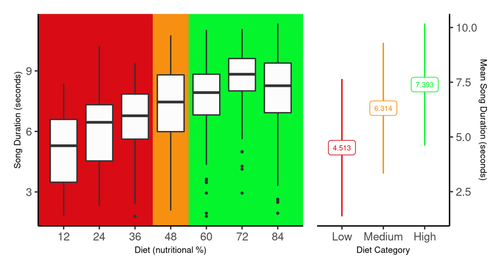

**Fig. 2 - LEFT:** The nutritional percentage of a crickets diet increases the total length of time (in seconds) spent singing over the observational period of 1 week. Each 12% increase in nutrition lengthened song duration by 0.37 seconds [95% CI; 0.30-0.44]. The background colours surrounding the boxes show the nutritional category of the diet; red representing Low, orange for Medium, and green for High. The median, interquartile range, and range for each nutritional percentage are respectively illustrated by the middle line, box, and whiskers on their plot. Outliers are shown as circular filled plots. **RIGHT:** The mean song duration in seconds is presented to 4 significant figures for each nutritional category - Low (<=36%), Medium(=48%), and High(>=60%). Error bars extend one standard deviation above and below the mean.

##### **SIGNIFICANCE AND CONCLUSIONS**

Song length is significant as a male cricket’s ability to sing for a greater duration than their peers has a great impact on their fitness, something which is facilitated by their nutrition. A longer song would suggest a greater chance of mating through the principles of sexual selection.

Males of a species competing against each other for the opportunity to mate with a female is a common occurrence in nature (Cox and Le Boeuf 1977; Lande 1981; Andersson 1994). These competitions can manifest as direct antagonism where males get into a physical conflict. Such is the case with red deer, as growing larger antlers to fight with correlates to a greater level of reproductive success (Kruuk et al. 2002). The other way that males can outshine their peers is through courtship displays which are aimed to impress the females, as is true of the singing behaviour found in *Gryllodes sigillatus*. Another well-known example of this includes male birds such as peacocks sporting a large ornamental plumage, a trait which is selected for by female choice (Lande 1981). In the wild, this colourful addition could be seen as counter-intuitive for survival, making it more difficult to hide from and escape predators (Burk 1982). The same could be said for the cricket - producing a loud acoustic for an extended time could alert predators to the individual’s location. However, this is exactly why it is so attractive to females of the species - If an individual can survive despite their handicap they must be of good fitness, a quality that females will want to pass on to their offspring (Andersson 1986). Individuals of greater fitness are more desirable mates, so acts that can display a male’s fitness to females are crucial to their reproductive success, which includes song production in crickets.

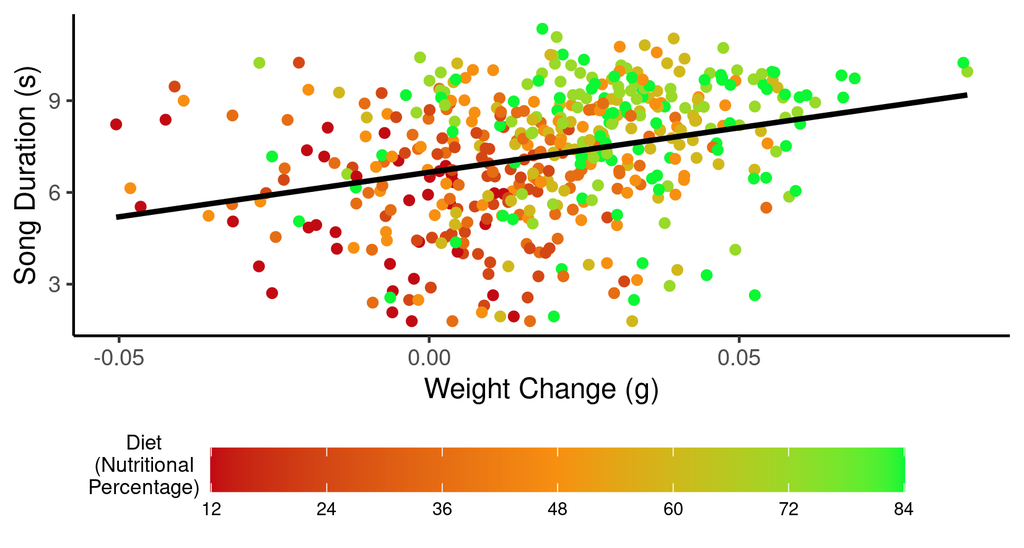

As this investigation found that greater nutrition corresponds with an increased song duration, maintaining a quality diet is important for the success of male crickets. Nutrition also facilitates weight gain which also increases a male’s chance of winning over a mate, as not only are female *Gryllodes sigillatus* attracted to longer acoustic displays, but they also prefer the songs of bigger individuals (Kiflawi and Gray 2000). Whilst this was found to be true in regards to weight in this data, wherein the crickets consuming a more nutritional diet were both gaining more mass and generally producing a longer song, it was seen that size in terms of a cricket’s length did not have a significant influence over song duration which may be a downfall of the data and require further investigation.

It could be concluded from these results that the length of song produced by *Gryllodes sigillatus* males is what indicates their fitness and therefore potential as a mate to females of the species, so a longer song would increase an individual’s chance of mating. It is known from previous research that individuals with a greater level of fitness require lower metabolic maintenance and are also better able to allocate resources (Ketola and Kotiaho 2009). This means that fitter individuals would have more surplus resources to put towards the production of a signalling song, especially when on a highly nutritious diet. In this way, nutrition has influence over the reproductive success of male *Gryllodes sigillatus*, due to the increased availability of resources available for complex mating behaviours once basic energetic needs are met. A further investigation stemming from these results could look at a quantification of fitness compared to song duration to confirm the theory that singing demonstrates fitness.

### **References**

Andersson, Malte. 1986. “EVOLUTION OF CONDITION-DEPENDENT SEX ORNAMENTS AND MATING PREFERENCES: SEXUAL SELECTION BASED ON VIABILITY DIFFERENCES.” *Evolution* 40 (4): 804–16. https://doi.org/10.1111/j.1558-5646.1986.tb00540.x.

———. 1994. *Sexual Selection*. Princeton University Press. https://doi.org/10.1515/9780691207278.

Bateman, Philip W., and Duncan N. MacFadyen. 1999. “Mate Guarding in the Cricket Gryllodes Sigillatus: Influence of Multiple Potential Partners.” *Ethology* 105 (11): 949–57. https://doi.org/10.1046/j.1439-0310.1999.00484.x.

Bateman, Philip W., L. Verburgt, and J. W. H. Ferguson. 2005. “Exposure to Male Song Increases Rate of Egg Development in the Cricket Gryllodes Sigillatus.” *African Zoology* 40 (2): 323–26. https://doi.org/10.10520/EJC17961.

Burk, T. 1982. “Evolutionary Significance of Predation on Sexually Signalling Males.” *The Florida Entomologist* 65 (1): 90. https://doi.org/10.2307/3494148.

Cox, Cathleen R., and Burney J. Le Boeuf. 1977. “Female Incitation of Male Competition: A Mechanism in Sexual Selection.” *The American Naturalist* 111 (978): 317–35. https://doi.org/10.1086/283163.

Kassambara, Alboukadel. 2021. “Rstatix: Pipe-Friendly Framework for Basic Statistical Tests.” https://rpkgs.datanovia.com/rstatix/.

Ketola, T., and J. S. Kotiaho. 2009. “Inbreeding, Energy Use and Condition.” *Journal of Evolutionary Biology* 22 (4): 770–81. https://doi.org/10.1111/j.1420-9101.2009.01689.x.

Kiflawi, Moshe, and David A. Gray. 2000. “Sizedependent Response to Conspecific Mating Calls by Male Crickets.” *Proceedings of the Royal Society of London. Series B: Biological Sciences* 267 (1458): 2157–61. https://doi.org/10.1098/rspb.2000.1263.

Kruuk, Loeske E. B., Jon Slate, Josephine M. Pemberton, Sue Brotherstone, Fiona Guinness, and Tim Clutton-Brock. 2002. “ANTLER SIZE IN RED DEER: HERITABILITY AND SELECTION BUT NO EVOLUTION.” *Evolution* 56 (8): 1683–95. https://doi.org/10.1111/j.0014-3820.2002.tb01480.x.

Lande, Russell. 1981. “Models of Speciation by Sexual Selection on Polygenic Traits.” *Proceedings of the National Academy of Sciences* 78 (6): 3721–25. https://doi.org/10.1073/pnas.78.6.3721.

Lüdecke, Daniel, Mattan S. Ben-Shachar, Indrajeet Patil, Philip Waggoner, and Dominique Makowski. 2021. “Performance: An r Package for Assessment, Comparison and Testing of Statistical Models” 6: 3139. https://doi.org/10.21105/joss.03139.

Ou, Jianhong. 2021. “colorBlindness: Safe Color Set for Color Blindness.”

Pedersen, Thomas Lin. 2022. “Patchwork: The Composer of Plots.”

R Core Team. 2023. *R: A Language and Environment for Statistical Computing*. Vienna, Austria: R Foundation for Statistical Computing. https://www.R-project.org/.

Robinson, David, Alex Hayes, and Simon Couch. 2022. “Broom: Convert Statistical Objects into Tidy Tibbles.”

Slansky Jr., Frank. 1982. “Insect Nutrition: An Adaptationist’s Perspective.” *The Florida Entomologist* 65 (1): 45. https://doi.org/10.2307/3494145.

Subramaniam, M., and T. Subramoniam. 1990. “Mating Behaviour and Spermatophore Transfer in *Gryllodes Sigillatus* (Walker) (Orthoptera: Gryllidae).” *Mitteilungen Aus Dem Museum Für Naturkunde in Berlin. Zoologisches Museum Und Institut Für Spezielle Zoologie (Berlin)* 66 (1): 65–71. https://doi.org/10.1002/mmnz.19900660108.

Venables, W. N., and B. D. Ripley. 2002. “Modern Applied Statistics with s.” https://www.stats.ox.ac.uk/pub/MASS4/.

Wickham, Hadley, Mara Averick, Jennifer Bryan, Winston Chang, Lucy D’Agostino McGowan, Romain François, Garrett Grolemund, et al. 2019. “Welcome to the Tidyverse” 4: 1686. https://doi.org/10.21105/joss.01686.